# Dashboard Hub

The following dashboards are organized according to our [evaluation plan](https://datahub.teachinglab.org/evaluation_plan.html) and can also be found at the [data collection overview and data access guide](https://docs.google.com/document/d/1yvo1cW5i3OXtzN3Lf1lCRgw06Efbt0CH7n6PM53kELI/edit).

## Participant Perceptions

Participant perceptions include data from the end of session survey administered at the end of each PL session, end of course survey administered at the end of each PL course, ongoing coaching survey administered at the end of each coaching session, and end of coaching data, administered at the end of every coaching series. Lastly, NPS data is also prompted in this survey.

[Participant Feedback Full Report](https://teachinglabhq.shinyapps.io/OngoingReport_23_24/)

View all forms of p+articipant feedback and NPS simultaneously in section 2

[Participant Feedback Internal Rollup](https://teachinglabhq.shinyapps.io/tl_facilitator_data/)

[figure not shown]

View all participant feedback data with additional functionality and time-incorporated data

[Participant Feedback Qualtrics Data](https://teachinglab.co1.qualtrics.com/reporting-dashboard/web/6317cbd1f9feca001046524d)

[Access qualtrics dashboards using the information here](https://docs.google.com/document/d/1oD5mCtSMK8atMZknPruhgf6qToAA5oF7HyZQTil3i4w/edit)

## Participant Mindsets

Participant mindsets come from the diagnostic educator survey and follow up educator survey.

[Educator Survey Full Report](https://teachinglabhq.shinyapps.io/OngoingReport_23_24/)

View demographic information in section 1, teacher mindsets in section 4, and school leader mindsets in section 5

[Educator Survey Qualtrics Data](https://teachinglab.co1.qualtrics.com/reporting-dashboard/#/dashboard/63053d35379f890010cc456e?pageId=Page_fcc6840b-679e-4652-b50c-6a95853b5887)

[Access qualtrics dashboards using the information here](https://docs.google.com/document/d/1oD5mCtSMK8atMZknPruhgf6qToAA5oF7HyZQTil3i4w/edit)

## Participant Knowledge

Participants that completed [course assessments](https://docs.google.com/document/d/1t43JudOR4AlIk8ALdPp1V9UgZH8mWmybrDdDp2085mQ/edit?usp=sharing) will answer multiple choice quiz questions that address pedagogical content knowledge.

[Course Assessments Dashboard](https://teachinglabhq.shinyapps.io/course_assessments/)

[figure not shown]

View course assessments data as % correct before/after, % correct by each question, and finally % selected within each question!

[Course Assessments Ongoing Report](https://teachinglab.co1.qualtrics.com/reporting-dashboard/#/dashboard/63053d35379f890010cc456e?pageId=Page_fcc6840b-679e-4652-b50c-6a95853b5887)

Additionally view overall course assessments data in the ongoing report.

## Participant Practices

Teaching Lab staff conduct classroom observations and capture [standards and shifts aligned instruction](https://achievethecore.org/category/1155/printable-versions) in the classroom observations survey. Those results will appear in the following dashboards.

[IPG Raw Data/Downloadable Dashboard](https://teachinglabhq.shinyapps.io/IPGRawDataDashboard/)

[figure not shown]

Download classroom observations data in a rolled up summative form, or view entire responses on a per-teacher basis

[IPG Ongoing Report Data](https://teachinglabhq.shinyapps.io/OngoingReport_23_24/)

View % positive indicators in section 6b and 6c.

[IPG Qualtrics Data](https://teachinglab.co1.qualtrics.com/reporting-dashboard/web/6349bfbbb614690016a0b7b1/pages/Page_120ba1a8-cea1-44d2-a7e0-19fd41fcc67a/view)

[Access qualtrics dashboards using the information here](https://docs.google.com/document/d/1oD5mCtSMK8atMZknPruhgf6qToAA5oF7HyZQTil3i4w/edit)

## Student Learning Experiences

Respondents to the student survey and submissions of student work samples have their responses rolled up and graded in the following dashboards.

[Student Survey Qualtrics Data](https://teachinglab.co1.qualtrics.com/reporting-dashboard/#/dashboard/6345c33160c27c00166cb726?pageId=Page_ee9d1195-c476-4414-b1ab-ee2da2fdb4ce)

[Access qualtrics dashboards using the information here](https://docs.google.com/document/d/1oD5mCtSMK8atMZknPruhgf6qToAA5oF7HyZQTil3i4w/edit)

[EIC Student Survey Qualtrics Data](https://teachinglab.co1.qualtrics.com/reporting-dashboard/#/dashboard/636172f94060140010530cc8?pageId=Page_35ff03a3-5111-48b5-abcd-ecfca4249e62)

[Access qualtrics dashboards using the information here](https://docs.google.com/document/d/1oD5mCtSMK8atMZknPruhgf6qToAA5oF7HyZQTil3i4w/edit)

[Student Work Grading Web App](https://teachinglabhq.shinyapps.io/student_work_samples/)

[figure not shown]

Grade student work assignments that have been submitted to Teaching Lab!

[Student Work Graded Dashboard](https://teachinglabhq.shinyapps.io/student_work_graded/)

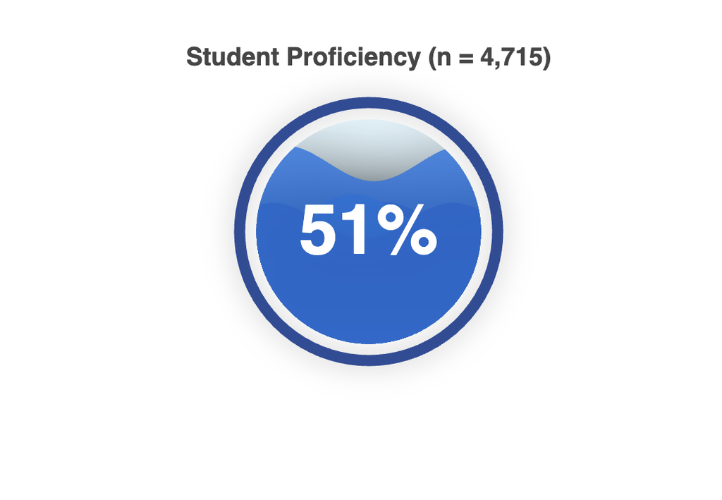

View the % proficient and on grade level after assignments have been submitted and graded in the above dashboard.

© Teaching Lab, 2023

*research@teachinglab.org*